# Chapter4

Julius Rissanen

17 helmikuuta 2017

# CHAPTER 4 CLUSTERING AND CLASSIFICATION

```r
#this week's needed packages
library(MASS)
library(dplyr)
library(GGally)
library(ggplot2)
library(tidyr)
library(corrplot)
library(plotly)
```

For this week we will be using ‘Boston’ dataset from the ‘MASS’ R package it includes 14 variables with 506 observations. Variables include:

1. per capita crime rate by town.
2. proportion of residential land zoned for lots over 25,000 sq.ft.
3. proportion of non-retail business acres per town.
4. Charles River dummy variable (= 1 if tract bounds river; 0 otherwise).
5. nitrogen oxides concentration (parts per 10 million).
6. average number of rooms per dwelling.
7. proportion of owner-occupied units built prior to 1940.
8. weighted mean of distances to five Boston employment centres.
9. index of accessibility to radial highways.
10. full-value property-tax rate per $10,000.
11. pupil-teacher ratio by town.
12. 1000(Bk - 0.63)^2 where Bk is the proportion of blacks by town.
13. lower status of the population (percent).
14. median value of owner-occupied homes in $1000s.

```r
data("Boston")
glimpse(Boston)
```

```
## Observations: 506
## Variables: 14
## $ crim    <dbl> 0.00632, 0.02731, 0.02729, 0.03237, 0.06905, 0.02985, ...
## $ zn      <dbl> 18.0, 0.0, 0.0, 0.0, 0.0, 0.0, 12.5, 12.5, 12.5, 12.5,...
## $ indus   <dbl> 2.31, 7.07, 7.07, 2.18, 2.18, 2.18, 7.87, 7.87, 7.87, ...
## $ chas    <int> 0, 0, 0, 0, 0, 0, 0, 0, 0, 0, 0, 0, 0, 0, 0, 0, 0, 0, ...
## $ nox     <dbl> 0.538, 0.469, 0.469, 0.458, 0.458, 0.458, 0.524, 0.524...
## $ rm      <dbl> 6.575, 6.421, 7.185, 6.998, 7.147, 6.430, 6.012, 6.172...
## $ age     <dbl> 65.2, 78.9, 61.1, 45.8, 54.2, 58.7, 66.6, 96.1, 100.0,...
## $ dis     <dbl> 4.0900, 4.9671, 4.9671, 6.0622, 6.0622, 6.0622, 5.5605...
## $ rad     <int> 1, 2, 2, 3, 3, 3, 5, 5, 5, 5, 5, 5, 5, 4, 4, 4, 4, 4, ...
## $ tax     <dbl> 296, 242, 242, 222, 222, 222, 311, 311, 311, 311, 311,...
## $ ptratio <dbl> 15.3, 17.8, 17.8, 18.7, 18.7, 18.7, 15.2, 15.2, 15.2, ...
## $ black   <dbl> 396.90, 396.90, 392.83, 394.63, 396.90, 394.12, 395.60...
## $ lstat   <dbl> 4.98, 9.14, 4.03, 2.94, 5.33, 5.21, 12.43, 19.15, 29.9...
## $ medv    <dbl> 24.0, 21.6, 34.7, 33.4, 36.2, 28.7, 22.9, 27.1, 16.5, ...
```

Next we look at the distributions and descriptive statistics of the Boston dataset.

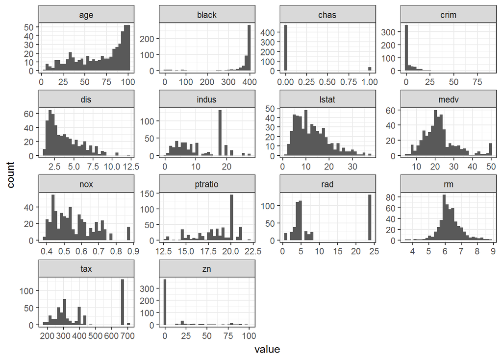

```r
gather(Boston) %>%
  ggplot(aes(value)) + facet_wrap("key", scales= "free") + geom_histogram() + theme_bw()
```

```r
summary(Boston)
```

```
##       crim                zn             indus            chas
##  Min.   : 0.00632   Min.   :  0.00   Min.   : 0.46   Min.   :0.00000
##  1st Qu.: 0.08204   1st Qu.:  0.00   1st Qu.: 5.19   1st Qu.:0.00000
##  Median : 0.25651   Median :  0.00   Median : 9.69   Median :0.00000
##  Mean   : 3.61352   Mean   : 11.36   Mean   :11.14   Mean   :0.06917
##  3rd Qu.: 3.67708   3rd Qu.: 12.50   3rd Qu.:18.10   3rd Qu.:0.00000
##  Max.   :88.97620   Max.   :100.00   Max.   :27.74   Max.   :1.00000
##       nox               rm             age              dis
##  Min.   :0.3850   Min.   :3.561   Min.   :  2.90   Min.   : 1.130
##  1st Qu.:0.4490   1st Qu.:5.886   1st Qu.: 45.02   1st Qu.: 2.100
##  Median :0.5380   Median :6.208   Median : 77.50   Median : 3.207
##  Mean   :0.5547   Mean   :6.285   Mean   : 68.57   Mean   : 3.795
##  3rd Qu.:0.6240   3rd Qu.:6.623   3rd Qu.: 94.08   3rd Qu.: 5.188
##  Max.   :0.8710   Max.   :8.780   Max.   :100.00   Max.   :12.127
##       rad              tax           ptratio          black
##  Min.   : 1.000   Min.   :187.0   Min.   :12.60   Min.   :  0.32
##  1st Qu.: 4.000   1st Qu.:279.0   1st Qu.:17.40   1st Qu.:375.38
##  Median : 5.000   Median :330.0   Median :19.05   Median :391.44
##  Mean   : 9.549   Mean   :408.2   Mean   :18.46   Mean   :356.67
##  3rd Qu.:24.000   3rd Qu.:666.0   3rd Qu.:20.20   3rd Qu.:396.23
##  Max.   :24.000   Max.   :711.0   Max.   :22.00   Max.   :396.90
##      lstat            medv
##  Min.   : 1.73   Min.   : 5.00
##  1st Qu.: 6.95   1st Qu.:17.02
##  Median :11.36   Median :21.20
##  Mean   :12.65   Mean   :22.53
##  3rd Qu.:16.95   3rd Qu.:25.00
##  Max.   :37.97   Max.   :50.00
```

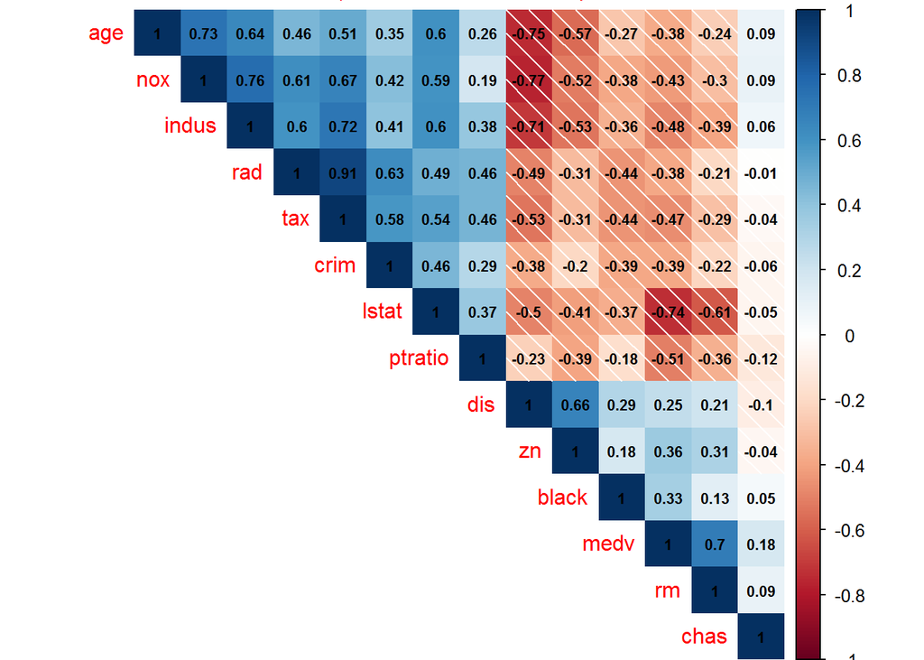

```r
Boston.corr <- cor(Boston)
corrplot(Boston.corr, type="upper", order = "AOE" ,method = "shade", addCoef.col = T, number.cex = 0.7)
```

Next we need to scale the Boston dataset for the use of LDA and convert it back to dataframe

```r
Boston.scaled <- scale(Boston)
summary(Boston.scaled)
```

```
##       crim                 zn               indus
##  Min.   :-0.419367   Min.   :-0.48724   Min.   :-1.5563
##  1st Qu.:-0.410563   1st Qu.:-0.48724   1st Qu.:-0.8668
##  Median :-0.390280   Median :-0.48724   Median :-0.2109
##  Mean   : 0.000000   Mean   : 0.00000   Mean   : 0.0000
##  3rd Qu.: 0.007389   3rd Qu.: 0.04872   3rd Qu.: 1.0150
##  Max.   : 9.924110   Max.   : 3.80047   Max.   : 2.4202
##       chas              nox                rm               age
##  Min.   :-0.2723   Min.   :-1.4644   Min.   :-3.8764   Min.   :-2.3331
##  1st Qu.:-0.2723   1st Qu.:-0.9121   1st Qu.:-0.5681   1st Qu.:-0.8366
##  Median :-0.2723   Median :-0.1441   Median :-0.1084   Median : 0.3171
##  Mean   : 0.0000   Mean   : 0.0000   Mean   : 0.0000   Mean   : 0.0000
##  3rd Qu.:-0.2723   3rd Qu.: 0.5981   3rd Qu.: 0.4823   3rd Qu.: 0.9059
##  Max.   : 3.6648   Max.   : 2.7296   Max.   : 3.5515   Max.   : 1.1164
##       dis               rad               tax             ptratio
##  Min.   :-1.2658   Min.   :-0.9819   Min.   :-1.3127   Min.   :-2.7047
##  1st Qu.:-0.8049   1st Qu.:-0.6373   1st Qu.:-0.7668   1st Qu.:-0.4876
##  Median :-0.2790   Median :-0.5225   Median :-0.4642   Median : 0.2746
##  Mean   : 0.0000   Mean   : 0.0000   Mean   : 0.0000   Mean   : 0.0000
##  3rd Qu.: 0.6617   3rd Qu.: 1.6596   3rd Qu.: 1.5294   3rd Qu.: 0.8058
##  Max.   : 3.9566   Max.   : 1.6596   Max.   : 1.7964   Max.   : 1.6372
##      black             lstat              medv
##  Min.   :-3.9033   Min.   :-1.5296   Min.   :-1.9063
##  1st Qu.: 0.2049   1st Qu.:-0.7986   1st Qu.:-0.5989
##  Median : 0.3808   Median :-0.1811   Median :-0.1449
##  Mean   : 0.0000   Mean   : 0.0000   Mean   : 0.0000
##  3rd Qu.: 0.4332   3rd Qu.: 0.6024   3rd Qu.: 0.2683
##  Max.   : 0.4406   Max.   : 3.5453   Max.   : 2.9865
```

```r
Boston.scaled <- as.data.frame(Boston.scaled)
```

```r
#crim variable to quantiles
crim.scaled <- Boston.scaled$crim
quantiles <- quantile(crim.scaled)

#quantile names
quantile.names <- c("low", "med_low", "med_high", "high")

# cut crime from original to new quantiles
crime.quantile <- cut(crim.scaled, breaks = quantiles, include.lowest = T, label = quantile.names)

Boston.scaled <- select(Boston.scaled, -crim)
Boston.scaled <- cbind(Boston.scaled, crime.quantile)
```

Next we break the data into test and training dataset

```r
n <- nrow(Boston.scaled)

#choose 80%
ind <- sample(n,  size = n * 0.8)

#training set
train <- Boston.scaled[ind,]

#test set
test <- Boston.scaled[-ind,]

# save classes from test data to a  independent variable
correct_classes <- test$crime.quantile

# remove crime from test
test <- dplyr::select(test, -crime.quantile)
```

Next we fit LDA to our training data. using crime.quantiles as target variable and other’s as predictors.

```r
lda.fit <- lda(crime.quantile ~ ., data=train)
lda.fit
```

```
## Call:
## lda(crime.quantile ~ ., data = train)
##
## Prior probabilities of groups:
##       low   med_low  med_high      high
## 0.2623762 0.2574257 0.2425743 0.2376238
##
## Group means:
##                   zn      indus       chas        nox          rm
## low       0.95541365 -0.8760050 -0.1237592 -0.8677723  0.42804593
## med_low  -0.09619246 -0.3165275  0.0305248 -0.5698471 -0.12471198
## med_high -0.40761122  0.2410563  0.1695903  0.3745051  0.03148331
## high     -0.48724019  1.0172418 -0.1492947  1.0233739 -0.44268865
##                 age        dis        rad        tax     ptratio
## low      -0.8739720  0.8629898 -0.6925875 -0.7265148 -0.42872908
## med_low  -0.3164801  0.3816493 -0.5556132 -0.4906283 -0.09493708
## med_high  0.3907287 -0.3853200 -0.4381072 -0.2995913 -0.14254161
## high      0.8034330 -0.8538845  1.6368728  1.5131579  0.77931510
##                black       lstat         medv
## low       0.37218947 -0.76252432  0.503155231
## med_low   0.31632821 -0.11830090  0.005319549
## med_high  0.09306857  0.03893808  0.132567217
## high     -0.96506056  0.92030250 -0.704534956
##
## Coefficients of linear discriminants:
##                 LD1         LD2         LD3
## zn       0.12663700  0.69811692 -0.98141410
## indus    0.02275846 -0.23399223  0.20294306
## chas    -0.05633175 -0.03711700  0.14726110
## nox      0.39998587 -0.81871018 -1.42628604
## rm       0.02533113 -0.02819606 -0.16499744
## age      0.24820527 -0.17530335 -0.02412568
## dis     -0.10761231 -0.26361266  0.27814469
## rad      3.42243029  1.07793935  0.01745111
## tax     -0.02799917 -0.14013561  0.58561186
## ptratio  0.13088995 -0.09707823 -0.38139073
## black   -0.11497685  0.01761865  0.11365824
## lstat    0.20317414 -0.28799846  0.36246975
## medv     0.06625010 -0.48185684 -0.24439818
##
## Proportion of trace:
##    LD1    LD2    LD3
## 0.9541 0.0338 0.0121
```

Next we draw the LDA (bi)plot to visualize the previous results from fitting the LDA.

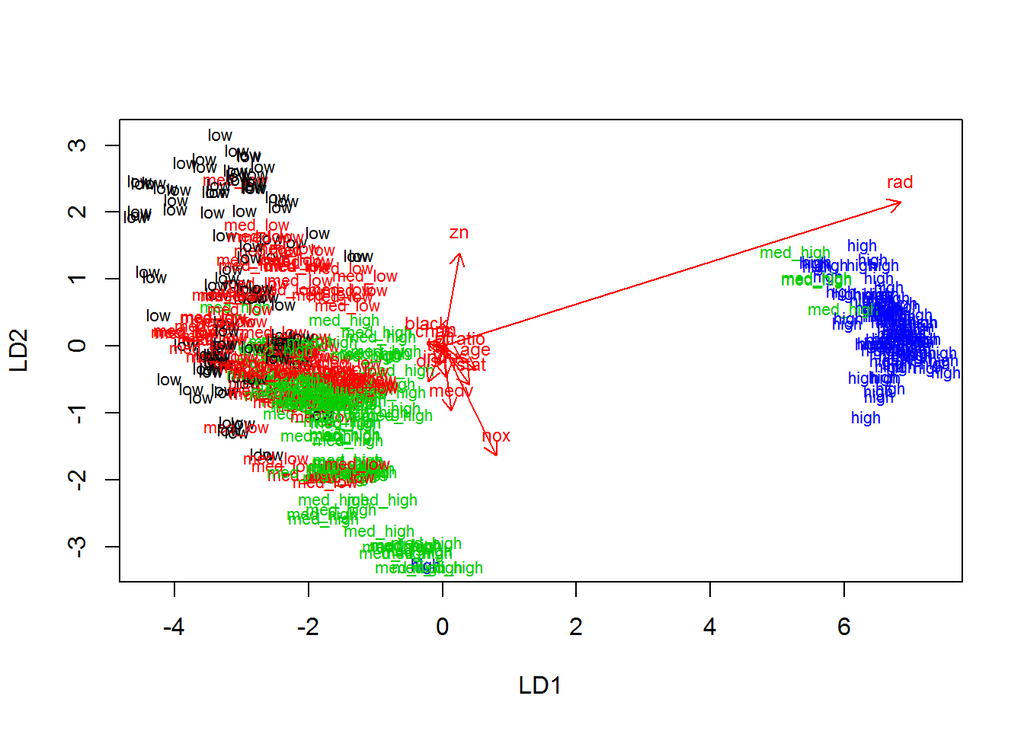

```r
lda.arrows <- function(x, myscale = 1, arrow_heads = 0.1, color = "red", tex = 0.75, choices = c(1,2)){
  heads <- coef(x)
  arrows(x0 = 0, y0 = 0,
         x1 = myscale * heads[,choices[1]],
         y1 = myscale * heads[,choices[2]], col=color, length = arrow_heads)
  text(myscale * heads[,choices], labels = row.names(heads),
       cex = tex, col=color, pos=3)
}

# target needs to be numeric
classes <- as.numeric(train$crime)

# plot
plot(lda.fit, dimen = 2, col = classes, pch = classes)
lda.arrows(lda.fit, myscale = 2)
```

From the picture can be seen that LD1 is good at separating high crime and then LD2 (up down) can further separate other 3 lower crime rates.

But next we see how well we can predict the classes

```r
lda.pred <- predict(lda.fit, newdata = test)

table(correct = correct_classes, predicted = lda.pred$class)
```

```
##           predicted
## correct    low med_low med_high high
##   low       13       7        1    0
##   med_low    3      14        5    0
##   med_high   0       9       17    2
##   high       0       0        0   31
```

Next we move on to utilising k-means with Boston dataset

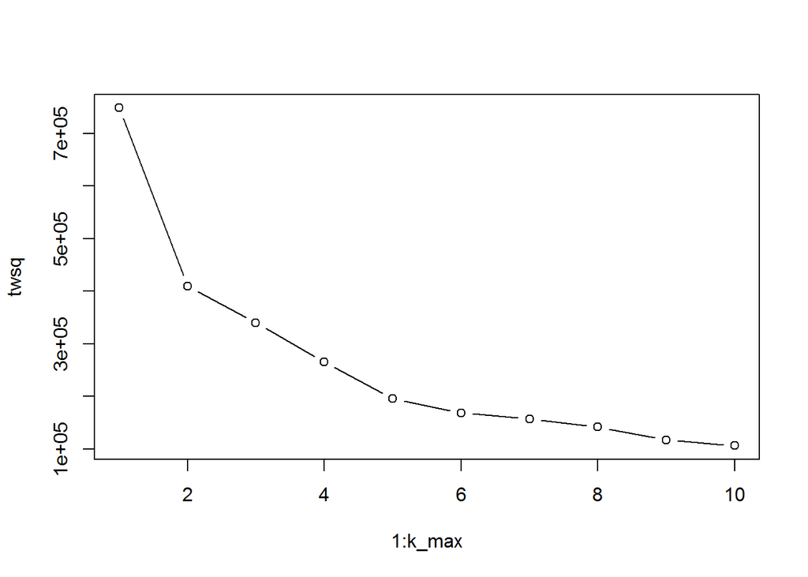

```r
data('Boston')

#clustering works only on scaled data
Boston.scaled2 <- scale(Boston)
set.seed(123)

#we need distance matrix for clustering
Boston.distance <- dist(Boston.scaled2)

#maximum number of hypothetical clusters

k_max <- 10

# total within sum of squares
twsq <- sapply(1:k_max, function(k){kmeans(Boston.distance, k)$tot.withinss})

plot(1:k_max, twsq, type = "b")
```

Inteptreting the graph looks like optimum number of clusters is 2 (has the sharpest drop in the within cluster variation). So next we run the kmeans for 2 clusters.

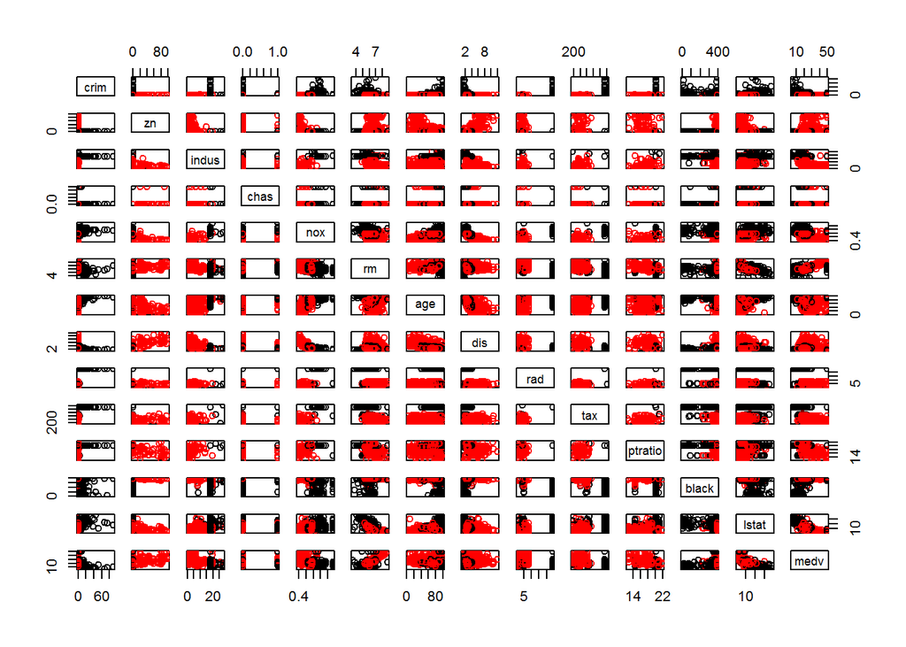

```r
boston.kmeans2 <- kmeans(Boston.distance, centers = 2)

#plot the dataset
pairs(Boston, col = boston.kmeans2$cluster)
```

From the graph we can see that rad and tax were most important separators for the clusters

### BONUS1:

I perform LDA using kmeans with 3 cluster centers.

```r
#kmeans with 3 clusters on Boston dataset
boston.kmeans3 <- kmeans(Boston.distance, centers = 3)

#LDA on the previous kmeans results
lda.fit <- lda(boston.kmeans3$cluster ~ ., data = Boston)
lda.fit
```

```
## Call:
## lda(boston.kmeans3$cluster ~ ., data = Boston)
##
## Prior probabilities of groups:
##         1         2         3
## 0.1699605 0.2964427 0.5335968
##
## Group means:
##        crim          zn     indus       chas       nox       rm      age
## 1 14.410307  1.04651163 18.412791 0.18604651 0.6955465 5.889453 92.21977
## 2  3.594889  0.08333333 16.201800 0.02666667 0.6192800 6.036413 88.09867
## 3  0.184901 20.91666667  6.005333 0.05555556 0.4739507 6.548407 50.19704
##        dis       rad      tax  ptratio    black     lstat     medv
## 1 1.810314 19.941860 616.1279 19.23721 231.9315 20.426628 16.44186
## 2 2.561713 12.773333 496.2600 19.56667 369.0913 16.157333 18.00800
## 3 5.112399  4.448148 293.1185 17.58926 389.5083  8.230222 26.98667
##
## Coefficients of linear discriminants:
##                  LD1           LD2
## crim    -0.030828366  0.0869664519
## zn      -0.015314358 -0.0059126472
## indus   -0.069679715 -0.0883096847
## chas    -1.339918668  1.6001162814
## nox     -5.141704866  3.0477474546
## rm       0.391059024 -0.3225584287
## age     -0.009923483 -0.0211950792
## dis      0.090002927  0.1210279332
## rad      0.046659074 -0.0163781763
## tax     -0.005000880 -0.0001812208
## ptratio -0.139896301 -0.0984855812
## black    0.006186019 -0.0092407719
## lstat   -0.072113484  0.0424045403
## medv    -0.037617137  0.0666347548
##
## Proportion of trace:
##    LD1    LD2
## 0.8828 0.1172
```

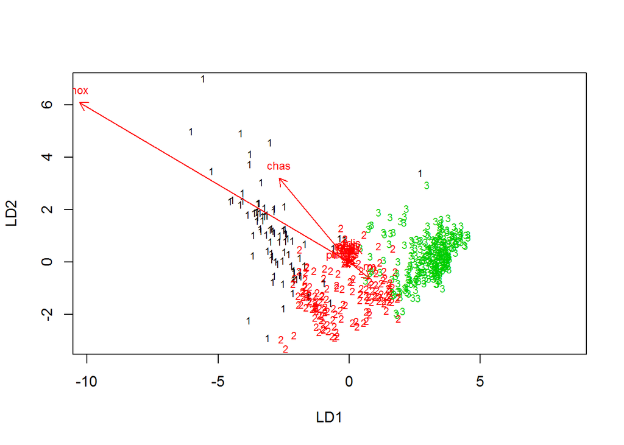

```r
#plot the previous lda
plot(lda.fit, dimen = 2, col = boston.kmeans3$cluster, pch = boston.kmeans3$cluster)
lda.arrows(lda.fit, myscale = 2)
```

From plotting the (bi)plot it can be seen that LD1 separates variables very well. Nox and Chas were the best ones.